Up to now, the representation of data has been in the form of graphics. Graphics are often easy to interpret (but not always). They can be used to identify patterns and relationships — this is termed *exploratory analysis*. They are also useful for telling a story — presenting a pattern or relationship that is important for some purpose.

But graphics are not always the best way to explore or to present data. Graphics work well when there are two or three or even four variables involved in the patterns to be explored or in the story to be told. Why two, three or four? Two variables can be represented with position on the paper or screen or, ultimately, the eye’s retina. To represent a third variable, color or size can be used. In principle, more variables can be represented by other graphical aesthetics: shape, angle, color saturation, opacity, facets, etc. Doing so raises problems for human cognition; people simply don’t do very well at integrating so many graphical modes into a coherent whole.

There are, of course, occasions when a multivariate graphical representation works. A famous example is [Charles Minard’s] map, made in 1869, of the march on Moscow of Napoleon’s army in 1812-1813.

[figure not shown]

Figurative map of the successive losses of men from the French Army in that Russian campaign 1812-1812. From [wikimedia](http://en.wikipedia.org/wiki/Wikipedia:Featured_picture_candidates/Napoleon's_Invasion_of_Russia). A higher resolution version is available [here](http://en.wikipedia.org/wiki/Wikipedia:Featured_picture_candidates/Napoleon's_Invasion_of_Russia#mediaviewer/File:Minard.png).

The map shows location (latitude and longitude), size of the army, terrain features, and expeditions off of the main force. The second graphic, on the bottom, shows time and temperature.

The Minard graphic is famous because it is exceptional. Such exceptions are not common.

In general, when dealing with multiple variables, a different mode of exploration or presentation is used: machine learning. This chapter introduces a few of the many methods of machine learning.

Keep in mind that with machine learning, as with graphics, techniques and operations are used to transfigure data into ready-to-use form. For graphics, this was called “glyph-ready form.” The same term will be used when working with machine learning, even though there are no glyphs.

### Regression or Learning?

The most important methods pre-date the introduction of the term “machine learning.” These are the *regression* techniques, particularly *linear least squares* and *logistic regression*.

Presenting the concepts of regression requires a book-length treatment. It’s inappropriate to do that here. Instead, this chapter will focus on machine-learning techniques that can be understood more intuitively. Do remember, however, that mastery of the regression techniques is an essential component of any well-trained data analyst.

## Supervised

A *function*, as you know, is a relationship between inputs and an output. Outdoor temperature is a function of season: season is the input; temperature is the output. Length of the day — i.e. how many hours of daylight — is a function of latitude and day of the year: latitude and day-of-the-year (e.g. March 22) are the inputs; day length is the output. Risk of colon cancer is a function of … well what?

There is a new bit of R syntax to help with defining functions: the tilde. The tilde is used to indicate what is the output variable and what are the input variables. You’ll see expressions like this:

```
diabetic ~ age + sex + weight + height
```

Here, the variable `diabetic` is marked as the output, simply because it’s to the left of the tilde. The variables `age`, `sex`, `weight`, and `height` are to be the inputs to the function. You’ll also see the syntax `diabetic ~ .`. The dot to the right of the tilde means “use all the available variables (except the output).”

There are several different goals that might motivate constructing a function:

- Predict the output given an input. It’s February, what will the temperature be? On June 15 in Saint Paul, Minnesota, USA (latitude 45 deg N), how many hours of daylight will there be.
- Determine which variables are useful inputs. It’s obvious from experience that temperature is a function of season. But in less familiar situations, e.g. colon cancer, the relevant inputs are uncertain or unknown.
- Generating hypotheses. For a scientist trying to figure out the causes of colon cancer, it can be useful to construct a predictive model, then look to see what variables turn out to be related to risk of colon cancer. For instance, you might find that diet, age, and blood pressure are risk factors for colon cancer. Knowing some physiology suggests that blood pressure is not a direct cause of colon cancer, but it might be that there is a common cause of blood pressure and cancer. That “might be” is a hypothesis, and one that you probably would not have thought of before finding a function relating risk of colon cancer to those inputs.
- Understand how a system works. For instance, a reasonable function relating hours of daylight to day-of-the-year and latitude reveals that the the northern and southern hemisphere have reversed patterns: long days in the southern hemisphere will be short days in the northern hemisphere.

Depending on your motivation, the kind of model and the input variables will differ. In understanding how a system works, the variables you use should be related to the actual, causal mechanisms involved, e.g. the genetics of cancer. For predicting an output, it hardly matters what the causal mechanisms are. Instead, all that’s required is that the inputs are known at a time *before* the prediction is to be made.

Consider the relationship between age and colon cancer. As with many diseases, the risk of colon cancer increases with age. Knowing this can be very useful in practice. For instance, it could help you design a screening program to test people for colon cancer. On the other hand, age does not suggest a way to avoid colon cancer: there’s no way for you to change your age. You can, however, change things like diet, physical fitness, etc.

*[Supervised learning](http://en.wikipedia.org/wiki/Supervised_learning)* (also known as *function fitting*) is the process of constructing a function from data. The defining thing about supervised learning is that the data you have includes as a variable the outcome of the function. With this outcome variable in hand, you can try many different possible functions of input variables and choose those that give a good match to the actual outcome.

Another broad category of machine learning is *unsupervised* learning. More about that later.

The *form* or *architecture* of a function refers to the mathematics behind the function and the approach to finding a specific function that is a good match to the data. Examples of the names of such forms are *linear least squares*, *logistic regression*, *neural networks*, *radial basis functions*, *discriminant functions*, *nearest neighbors*, etc.

Here the focus will be on a single, general-purpose function architecture: *recursive partitioning*. Software for constructing recursive partitioning function is in the `party` package:

```r
library(party)
```

To start, take a very familiar condition: pregnancy. You already know what factors predict pregnancy, so you can compare the findings of the machine learning technique of recursive partitioning to what you already know.

The `party::ctree()` function builds a recursive-partitioning function. The `NHANES` data has a variable `pregnant` that identifies whether the person is pregnant.

```r
whoIsPregnant <-
  ctree( pregnant ~ age + income + sex, data=NHANES )
```

There are different ways to look at the function contained in `whoIsPregnant`. An important one is the output produced for any given input. Here’s how to calculate that output when the inputs are an age of 25 (years), an income of 6 (times the poverty threshold), and sex female:

```r
f <- funCT( whoIsPregnant ) # get the function
f( age=25, income=6, sex="female")
```

```
  age income    sex       yes        no
1  25      6 female 0.3859649 0.6140351
```

The input values are repeated to make it easier to compare inputs to outputs. Since the output is a yes-or-no, the output is given as the probability of each of these. So, for a 25-year-old woman with an income level of 6, the probability of being pregnant is 38.6%.

Another way to look at a recursive partitioning function is as a “decision tree”.

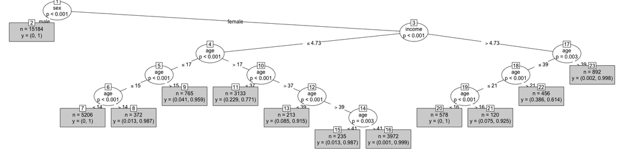

```r
plot(whoIsPregnant, type="simple")
```

To read the tree, start at the top. The top node, drawn as an oval, specifies the variable `sex`. From that oval there are two branches: one labeled “male” and the other “female.” This is the partitioning of the node from which the branches stem. As you follow a branch, you may come to another node, which itself branches, or you may come to a terminal (shown in the gray box). The terminal gives the output of the model.

Within each node there is a notation like $p < 0.001$. This is not part of the function itself. Instead, it reflects the process by which the function was constructed. Roughly speaking, $p < 0.001$ means there’s less than a 1-in-1000 chance that the node’s two branches are really the same.[^1]

What has been learned in constructing this function. First, without having been told that `sex` is related to pregnancy, the recursive partitioning has figured out that sex makes a difference; only females get pregnant. Of course you knew that already, but the machine learned that fact from the data. The machine also identified the fact that females under 14 years old are not likely to be pregnant, and women over 40 are also unlikely to be pregnant. Again, you knew that already, but the machine learned it from the data. The machine also learned something that might be unfamiliar to you, that age patterns of pregnancy are different for low-income and high-income people.

It might be easier to see the income-related patterns by looking at the specific model outputs. Here’s the function’s output for low-income females from 10 to 20 years old:

```r
f( age=10:20, income=3, sex="female")
```

```
   age income    sex          yes        no
1   10      3 female 0.0003841721 0.9996158
2   11      3 female 0.0003841721 0.9996158
3   12      3 female 0.0003841721 0.9996158
4   13      3 female 0.0003841721 0.9996158
5   14      3 female 0.0003841721 0.9996158
6   15      3 female 0.0134408602 0.9865591
7   16      3 female 0.0405228758 0.9594771
8   17      3 female 0.0405228758 0.9594771
9   18      3 female 0.2288541334 0.7711459
10  19      3 female 0.2288541334 0.7711459
11  20      3 female 0.2288541334 0.7711459
```

And for high-income females:

```r
f( age=25, income=6, sex="female")
```

```
  age income    sex       yes        no
1  25      6 female 0.3859649 0.6140351
```

Part of the machine learning is finding out which variables appear to be useful in matching the patterns of pregnancy in the NHANES data. For instance, the following recursive-partitioning tree can make use of several more variables. To avoid rediscovering the obvious, only females will be considered.

```r
whoIsPregnant2 <-
  ctree( pregnant ~
           age + income + ethnicity +
           height + smoker + bmi,
         data=NHANES %>% filter(sex=="female") )
```

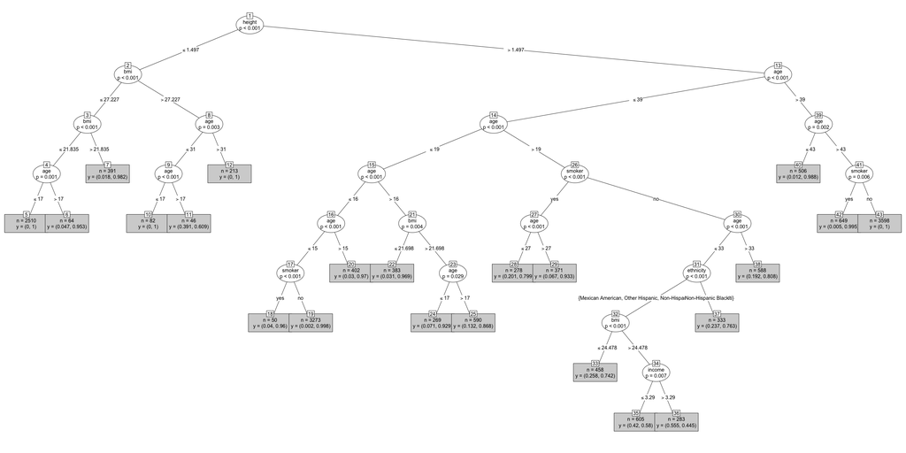

```r
plot( whoIsPregnant2, type="simple")
```